# Palmer Penguin Dataset Analysis

Tarek Zaatar

# Introduction

This is high level analysis report of the Palmer Penguin Dataset collected by Dr. Kristen Gorman. The report will cover general analysis about the dataset, then will move into investigating the relationship between the physical characteristics of the different species of penguins. For more details on the problem see https://allisonhorst.github.io/palmerpenguins/index.html.

# Analysis

The following section will show the steps of the analysis showing sample code and output. During the analysis we will try to answer the following questions:

- Is there a relationship between penguin’s body mass and bill length?
- Is there a relationship between penguin’s body mass and flipper length?
- Does the sex, species or location of the penguin effect the physical characteristics?

## Installing necessary packages

```r
install.packages("palmerpenguins")
install.packages("tidyverse")
install.packages("dplyr")
```

## Load the required packages

```r
library(tidyverse)
library(palmerpenguins)
library(dplyr)
library(skimr)
```

## Data exploration

Take a quick look at the data.

```r
head(penguins)
```

| species | island | bill_length_mm | bill_depth_mm | flipper_length_mm | body_mass_g | sex | year |
| --- | --- | --- | --- | --- | --- | --- | --- |
| Adelie | Torgersen | 39.1 | 18.7 | 181 | 3750 | male | 2007 |
| Adelie | Torgersen | 39.5 | 17.4 | 186 | 3800 | female | 2007 |
| Adelie | Torgersen | 40.3 | 18.0 | 195 | 3250 | female | 2007 |
| Adelie | Torgersen | NA | NA | NA | NA | NA | 2007 |
| Adelie | Torgersen | 36.7 | 19.3 | 193 | 3450 | female | 2007 |
| Adelie | Torgersen | 39.3 | 20.6 | 190 | 3650 | male | 2007 |

Display the columns name.

```r
colnames(penguins)
```

```
## [1] "species"           "island"            "bill_length_mm"
## [4] "bill_depth_mm"     "flipper_length_mm" "body_mass_g"
## [7] "sex"               "year"
```

View general structure of the data

```r
str(penguins)
```

```
## tibble [344 × 8] (S3: tbl_df/tbl/data.frame)
##  $ species          : Factor w/ 3 levels "Adelie","Chinstrap",..: 1 1 1 1 1 1 1 1 1 1 ...
##  $ island           : Factor w/ 3 levels "Biscoe","Dream",..: 3 3 3 3 3 3 3 3 3 3 ...
##  $ bill_length_mm   : num [1:344] 39.1 39.5 40.3 NA 36.7 39.3 38.9 39.2 34.1 42 ...
##  $ bill_depth_mm    : num [1:344] 18.7 17.4 18 NA 19.3 20.6 17.8 19.6 18.1 20.2 ...
##  $ flipper_length_mm: int [1:344] 181 186 195 NA 193 190 181 195 193 190 ...
##  $ body_mass_g      : int [1:344] 3750 3800 3250 NA 3450 3650 3625 4675 3475 4250 ...
##  $ sex              : Factor w/ 2 levels "female","male": 2 1 1 NA 1 2 1 2 NA NA ...
##  $ year             : int [1:344] 2007 2007 2007 2007 2007 2007 2007 2007 2007 2007 ...
```

Display Data summary

```r
skim_without_charts(penguins)
```

Data summary

| Name | penguins |
| --- | --- |
| Number of rows | 344 |
| Number of columns | 8 |
| _______________________ |  |
| Column type frequency: |  |
| factor | 3 |
| numeric | 5 |
| ________________________ |  |
| Group variables | None |

**Variable type: factor**

| skim_variable | n_missing | complete_rate | ordered | n_unique | top_counts |
| --- | --- | --- | --- | --- | --- |
| species | 0 | 1.00 | FALSE | 3 | Ade: 152, Gen: 124, Chi: 68 |
| island | 0 | 1.00 | FALSE | 3 | Bis: 168, Dre: 124, Tor: 52 |
| sex | 11 | 0.97 | FALSE | 2 | mal: 168, fem: 165 |

**Variable type: numeric**

| skim_variable | n_missing | complete_rate | mean | sd | p0 | p25 | p50 | p75 | p100 |
| --- | --- | --- | --- | --- | --- | --- | --- | --- | --- |
| bill_length_mm | 2 | 0.99 | 43.92 | 5.46 | 32.1 | 39.23 | 44.45 | 48.5 | 59.6 |
| bill_depth_mm | 2 | 0.99 | 17.15 | 1.97 | 13.1 | 15.60 | 17.30 | 18.7 | 21.5 |
| flipper_length_mm | 2 | 0.99 | 200.92 | 14.06 | 172.0 | 190.00 | 197.00 | 213.0 | 231.0 |
| body_mass_g | 2 | 0.99 | 4201.75 | 801.95 | 2700.0 | 3550.00 | 4050.00 | 4750.0 | 6300.0 |
| year | 0 | 1.00 | 2008.03 | 0.82 | 2007.0 | 2007.00 | 2008.00 | 2009.0 | 2009.0 |

```r
glimpse(penguins)
```

```
## Rows: 344
## Columns: 8
## $ species           <fct> Adelie, Adelie, Adelie, Adelie, Adelie, Adelie, Adel…
## $ island            <fct> Torgersen, Torgersen, Torgersen, Torgersen, Torgerse…
## $ bill_length_mm    <dbl> 39.1, 39.5, 40.3, NA, 36.7, 39.3, 38.9, 39.2, 34.1, …
## $ bill_depth_mm     <dbl> 18.7, 17.4, 18.0, NA, 19.3, 20.6, 17.8, 19.6, 18.1, …
## $ flipper_length_mm <int> 181, 186, 195, NA, 193, 190, 181, 195, 193, 190, 186…
## $ body_mass_g       <int> 3750, 3800, 3250, NA, 3450, 3650, 3625, 4675, 3475, …
## $ sex               <fct> male, female, female, NA, female, male, female, male…
## $ year              <int> 2007, 2007, 2007, 2007, 2007, 2007, 2007, 2007, 2007…
```

The following code shows how many males and females penguins are in the dataset.

```r
penguins %>% count(sex)
```

| sex | n |
| --- | --- |
| female | 165 |
| male | 168 |
| NA | 11 |

> Notice how the samples are almost equally collected, you can see that there are some missing values so we will have to deal with that before our analysis.

Filter out the rows where sex is NA

```r
filtered_data <- penguins %>% filter(sex != 'NA')
```

Display Data summary on the filtered data

```r
filtered_data %>% summary()
```

```
##       species          island    bill_length_mm  bill_depth_mm
##  Adelie   :146   Biscoe   :163   Min.   :32.10   Min.   :13.10
##  Chinstrap: 68   Dream    :123   1st Qu.:39.50   1st Qu.:15.60
##  Gentoo   :119   Torgersen: 47   Median :44.50   Median :17.30
##                                  Mean   :43.99   Mean   :17.16
##                                  3rd Qu.:48.60   3rd Qu.:18.70
##                                  Max.   :59.60   Max.   :21.50
##  flipper_length_mm  body_mass_g       sex           year       body_mass_kg
##  Min.   :172       Min.   :2700   female:165   Min.   :2007   Min.   :2.700
##  1st Qu.:190       1st Qu.:3550   male  :168   1st Qu.:2007   1st Qu.:3.550
##  Median :197       Median :4050                Median :2008   Median :4.050
##  Mean   :201       Mean   :4207                Mean   :2008   Mean   :4.207
##  3rd Qu.:213       3rd Qu.:4775                3rd Qu.:2009   3rd Qu.:4.775
##  Max.   :231       Max.   :6300                Max.   :2009   Max.   :6.300
```

```r
skim_without_charts(filtered_data)
```

Data summary

| Name | filtered_data |
| --- | --- |
| Number of rows | 333 |
| Number of columns | 9 |
| _______________________ |  |
| Column type frequency: |  |
| factor | 3 |
| numeric | 6 |
| ________________________ |  |
| Group variables | None |

**Variable type: factor**

| skim_variable | n_missing | complete_rate | ordered | n_unique | top_counts |
| --- | --- | --- | --- | --- | --- |
| species | 0 | 1 | FALSE | 3 | Ade: 146, Gen: 119, Chi: 68 |
| island | 0 | 1 | FALSE | 3 | Bis: 163, Dre: 123, Tor: 47 |
| sex | 0 | 1 | FALSE | 2 | mal: 168, fem: 165 |

**Variable type: numeric**

| skim_variable | n_missing | complete_rate | mean | sd | p0 | p25 | p50 | p75 | p100 |
| --- | --- | --- | --- | --- | --- | --- | --- | --- | --- |
| bill_length_mm | 0 | 1 | 43.99 | 5.47 | 32.1 | 39.50 | 44.50 | 48.60 | 59.6 |
| bill_depth_mm | 0 | 1 | 17.16 | 1.97 | 13.1 | 15.60 | 17.30 | 18.70 | 21.5 |
| flipper_length_mm | 0 | 1 | 200.97 | 14.02 | 172.0 | 190.00 | 197.00 | 213.00 | 231.0 |
| body_mass_g | 0 | 1 | 4207.06 | 805.22 | 2700.0 | 3550.00 | 4050.00 | 4775.00 | 6300.0 |
| year | 0 | 1 | 2008.04 | 0.81 | 2007.0 | 2007.00 | 2008.00 | 2009.00 | 2009.0 |
| body_mass_kg | 0 | 1 | 4.21 | 0.81 | 2.7 | 3.55 | 4.05 | 4.78 | 6.3 |

Mean value of each column per penguin species

```r
penguins %>%
  group_by(species) %>%
  summarize(across(where(is.numeric), mean, na.rm = TRUE))
```

| species | bill_length_mm | bill_depth_mm | flipper_length_mm | body_mass_g | year | body_mass_kg |
| --- | --- | --- | --- | --- | --- | --- |
| Adelie | 38.79139 | 18.34636 | 189.9536 | 3700.662 | 2008.013 | 3.700662 |
| Chinstrap | 48.83382 | 18.42059 | 195.8235 | 3733.088 | 2007.971 | 3.733088 |
| Gentoo | 47.50488 | 14.98211 | 217.1870 | 5076.016 | 2008.081 | 5.076016 |

## Visualization

In this part we would like to visualize some of the data and try to extract some insights.

Display a bar plot to better visualize the sex column

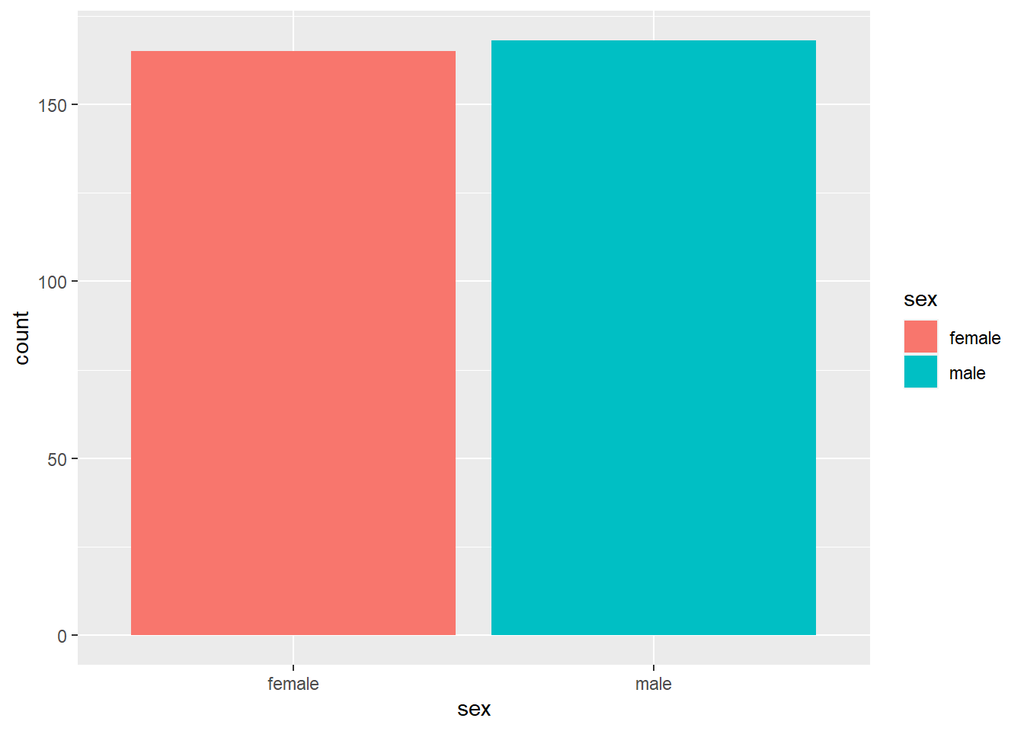

Repeat the same steps for the species column

| species | n |
| --- | --- |
| Adelie | 152 |
| Chinstrap | 68 |
| Gentoo | 124 |

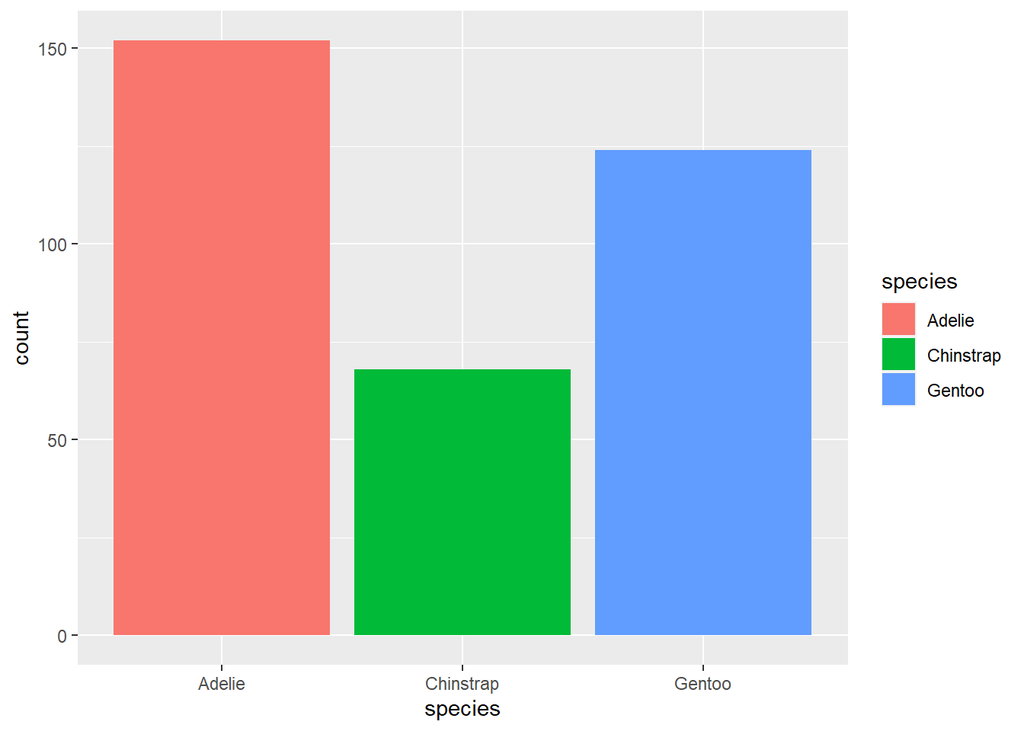

Create a scatter plot to show the relationship between flipper length and body mass

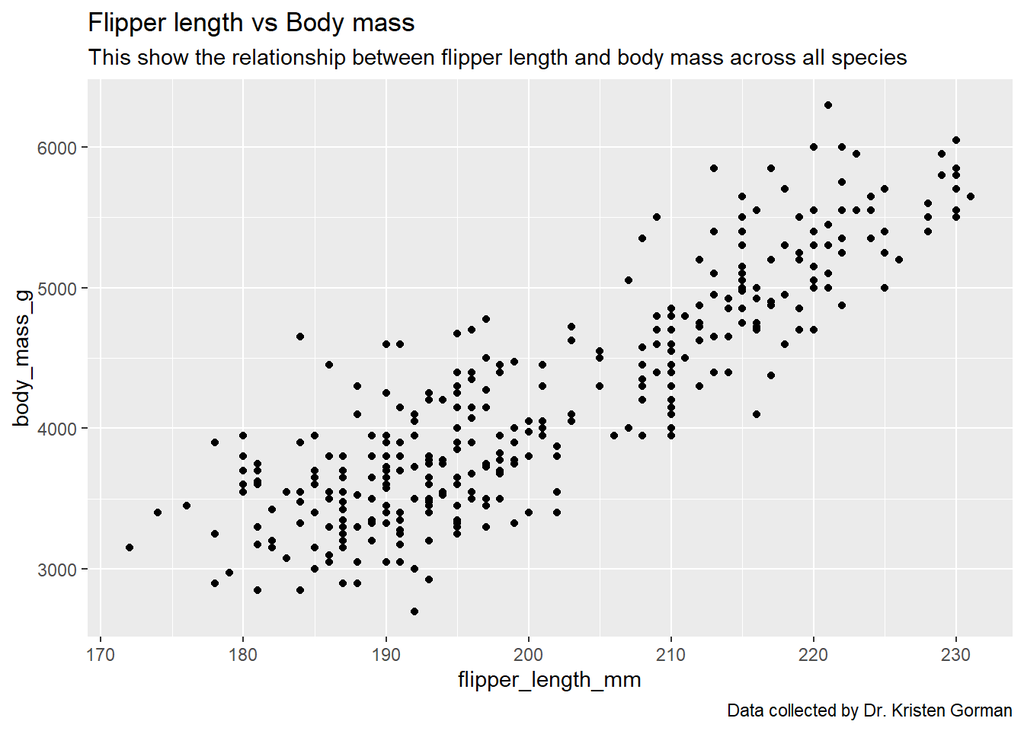

> You can see in the scatter plot that there is a relationship between flipper length and the body mass, the higher the body mass the longer the flipper length.

The following plots investigate if the above insight changes with the penguin species type.

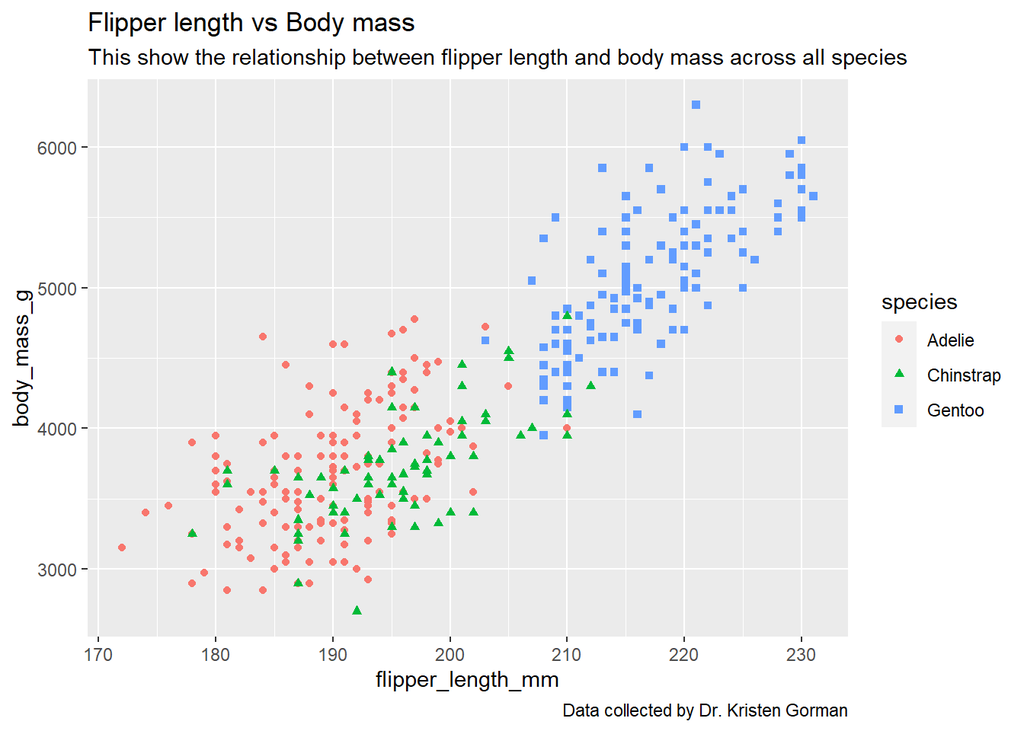

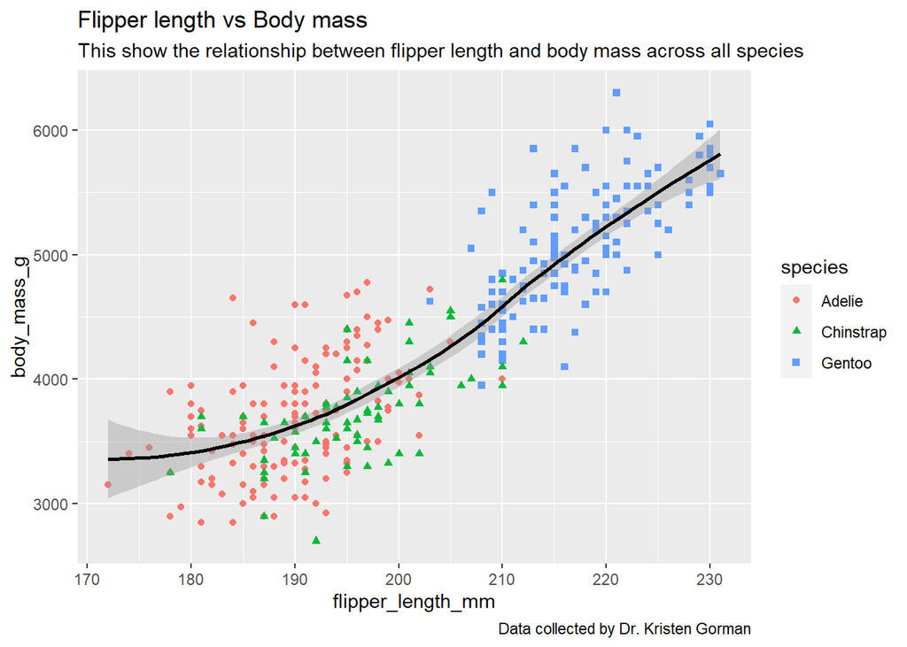

Visualizing each species alone.

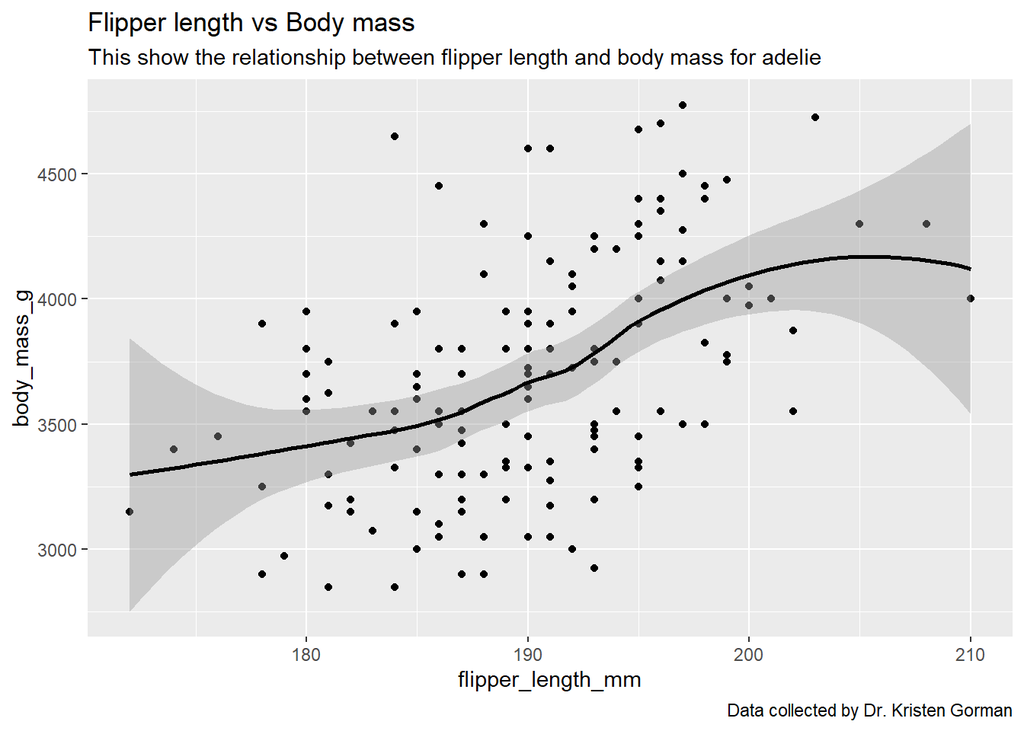

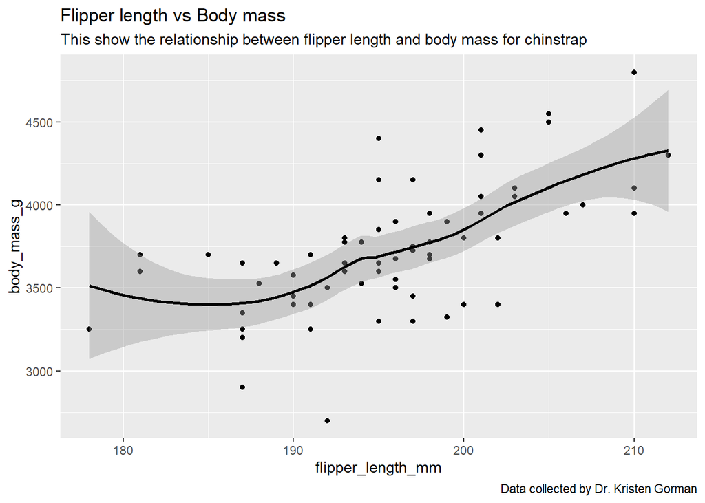

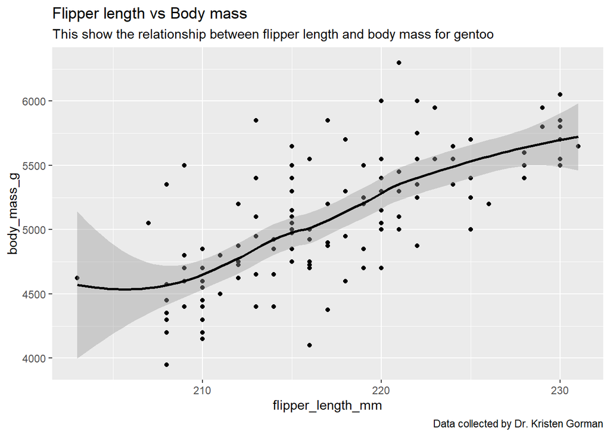

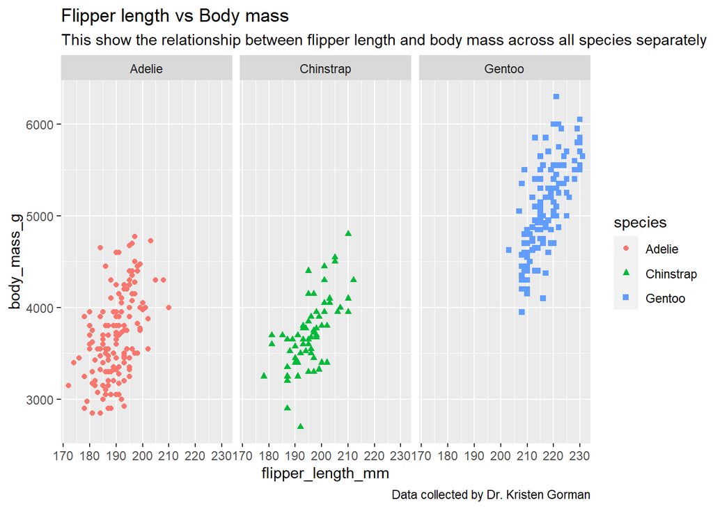

> As we have seen, there is a positive relationship between the flipper length and body mass regardless of the penguin type.

The following plots investigate if the above insight changes with the penguin sex.

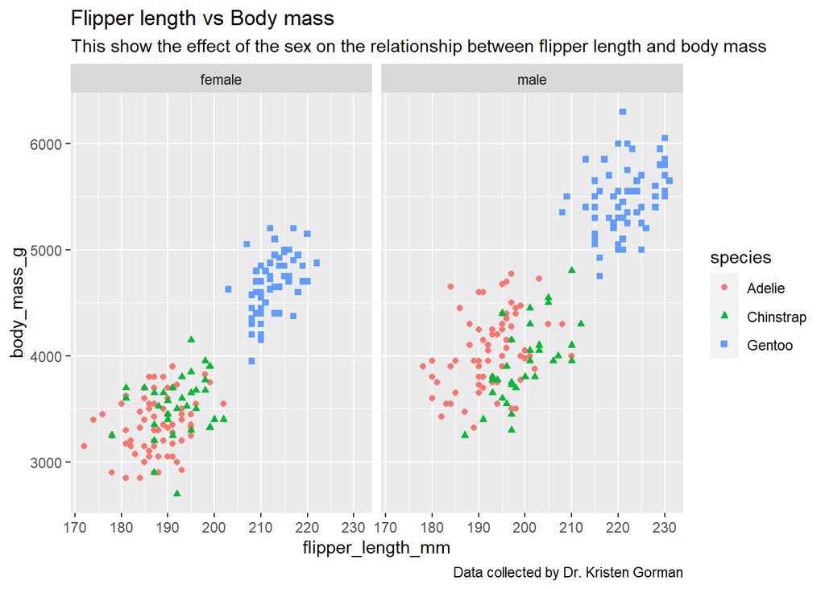

> As shown, penguin sex doesnt effect the relationship.

## Analyzing the relationship between bill length vs body mass

Repeating the same steps between penguin bill length and body mass

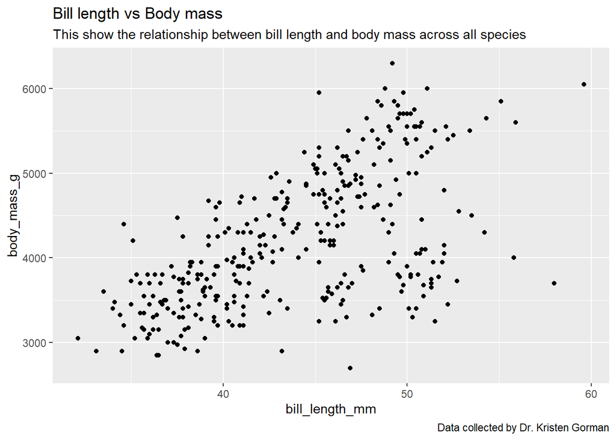

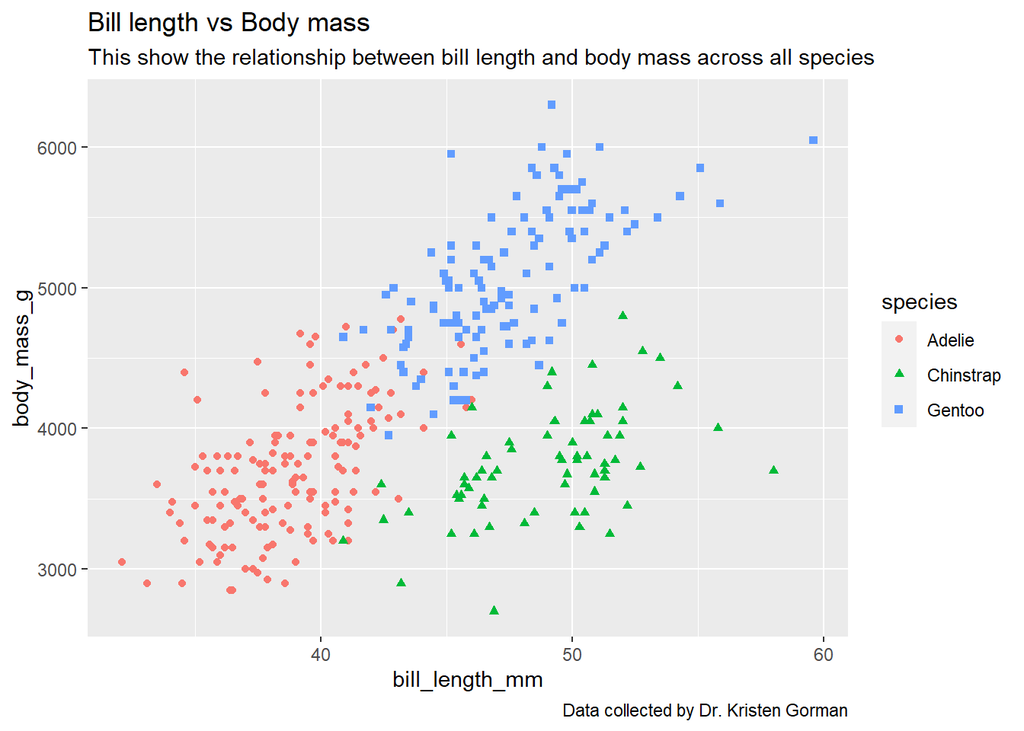

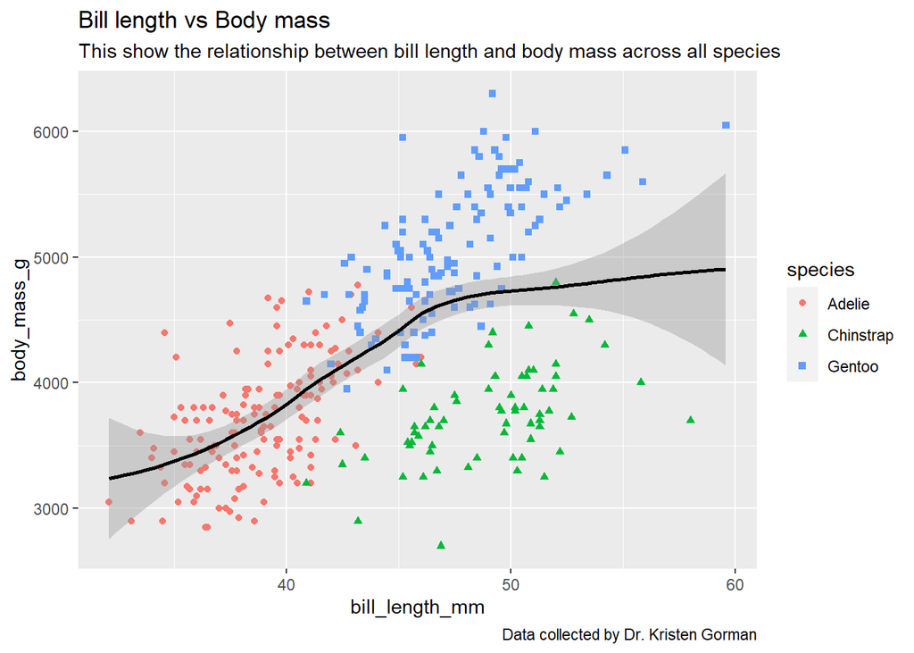

Visualizing each species alone.

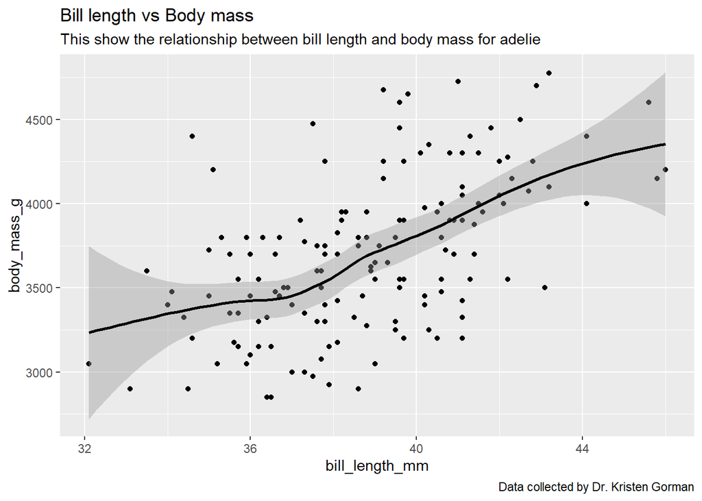

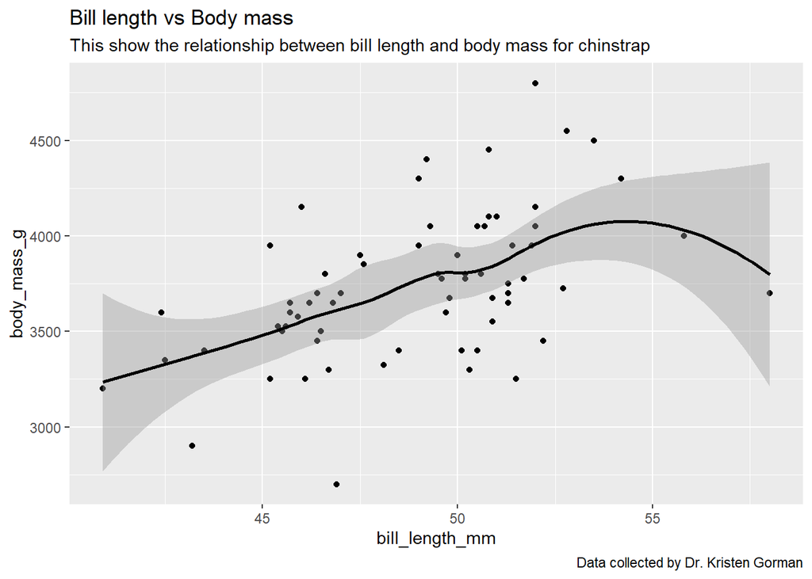

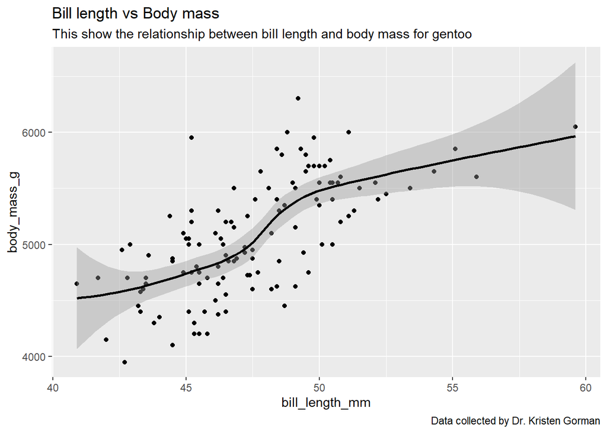

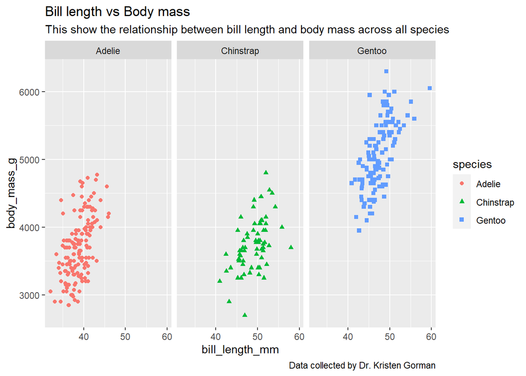

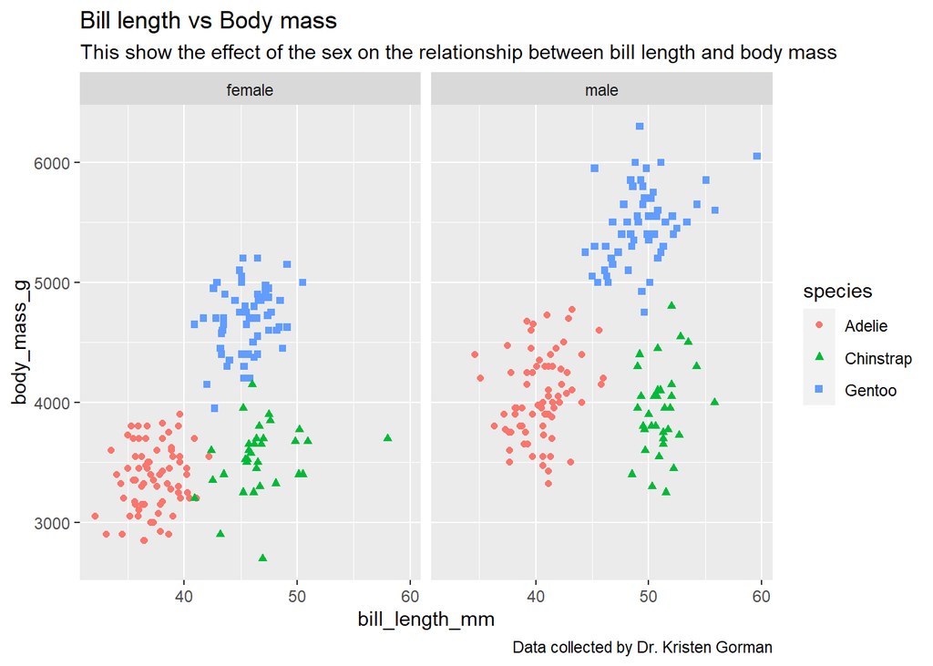

> As we have seen, there is a positive relationship between the bill length and body mass regardless of the sex or species type.

Analyzing the effect of the location on the relationship of the physical characteristics

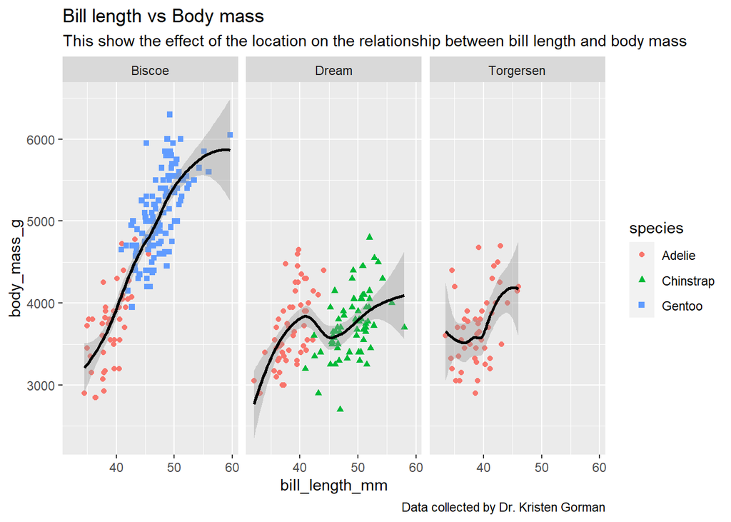

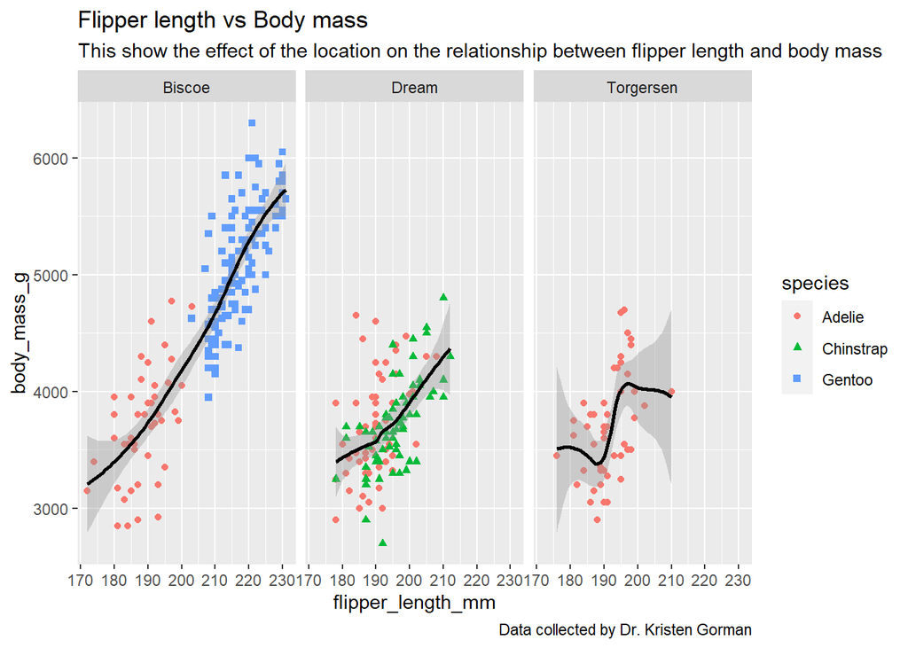

> The island where the penguin lives doesnt effect the positive relationship.

#Conclusion

- There is a positive relationship between the flipper length and body mass
- There is a positive relationship between the bill length and body mass
- Sex, species and location of the penguin doesnt effect the relationship between the physical characteristics